# Estudo de Caso 02: Avaliação e comparação do retorno médio de ações

Joao Paulo Lara Pinto, Thales Henrique de Oliveira Gonçalves, Henrique Alves Barbosa, Matheus Cascalho dos Santos

19 de Novembro de 2024

## Descrição do Problema

A escolha de um conjunto ideal de ações para serem investidas é um problema comum no ramo de ciências atuariais, sendo que modelos capazes de prever um portfolio ótimo de investimento são continuamente estudados e aprimorados [1].

Apesar de o ideal no mercado acionário ser a diversificação equilibrada com a escolha de um portfólio administrável de forma eficiente [2], é possível surgirem situações em que a escolha de uma única ação frente a um conjunto seja tomada como um problema de decisão. Exemplos como esse podem ocorrer em fundos multimercados que necessitem de escolher uma única empresa para cada segmento de mercado de forma a manter as regras estabelecidas pelo fundo em questão.

Neste estudo de caso, avaliamos 5 ações de forma a identificar qual dentre elas pode ser considerada a melhor. Avaliamos questões pertinentes ao problema, tais como pressupostos assumidos, melhorias possíveis e futuros estudos.

# Análise Exploratória e Tratamento dos Dados

Inicialmente, é necessário realizar uma transformação da base de dados fornecida para este estudo de caso. Dado que nossa base de dados contém os preços de fechamento das ações para cada período, precisamos transformar estes dados de forma a conseguir analisar o ganho mensal da ação. Para isto, os seguintes pressupostos foram assumidos:

- Considere que o preço de abertura de um dado mês é idêntico ao preço de fechamento da mesma ação no mês anterior.
- Considere que as ações podem ser adquiridas de forma fracionária, se necessário, i.e., o montante financeiro será investido por completo em uma única ação.

A partir destes pressupostos, transformamos nossa base de dados através da seguinte fórmula:

$$Var_i = \frac{Preço_i -
Preço_{i-1}}{Preço_{i-1}}$$

Podemos realizar isto utilizando o seguinte código:

```r
file_path <- file.path(getwd(), "DadosAcoesGrupoG.csv")
dados <- read.csv(file_path, header = FALSE)

# Renomear as colunas
colnames(dados) <- c("1", "2", "3", "4", "5")

# Criar um novo data.frame para rentabilidades
rentabilidade <- data.frame(matrix(NA, nrow = nrow(dados), ncol = ncol(dados)))
colnames(rentabilidade) <- paste0("", colnames(dados))

# Calcular a rentabilidade para cada coluna
for (i in 1:ncol(dados)) {
  # Cálculo da rentabilidade: (valor atual - valor anterior) / valor anterior
  rentabilidade[1:(nrow(dados) - 1), i] <- (dados[1:(nrow(dados) - 1), i] - dados[2:nrow(dados), i]) / dados[2:nrow(dados), i]
}
```

É útil realizar uma análise exploratória nas distribuições de rendimento, de forma a compreendermos qual a melhor forma de se realizar os experimentos e quais hipóteses podemos buscar:

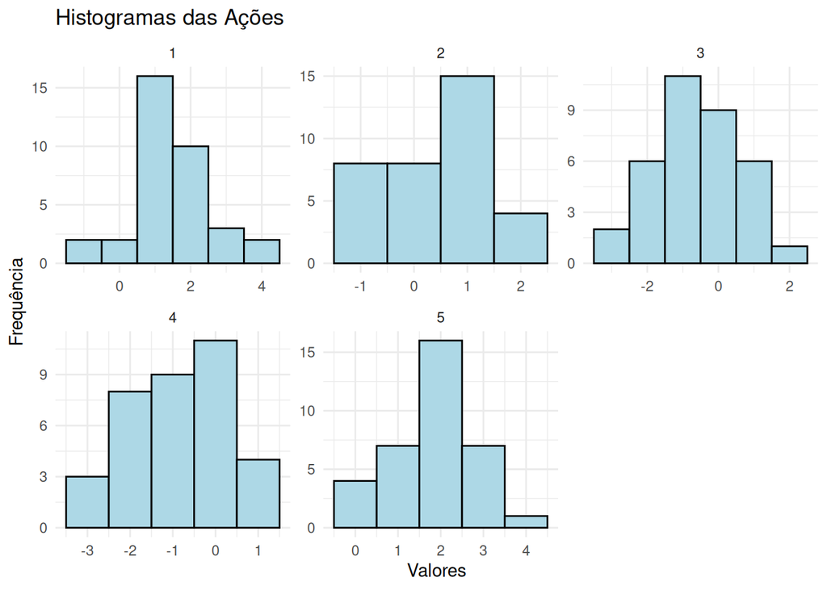

```r
library(ggplot2)
library(reshape2)

# Transformar o data frame em formato longo para usar com ggplot
# rentabilidade
rentabilidade <- na.omit(rentabilidade)
rentabilidade_classificada <- melt(rentabilidade*100, variable.name = "Ação", value.name = "Valor")
rentabilidade_classificada$Ação <- as.factor(rentabilidade_classificada$Ação)

# Plotar histogramas para cada coluna
ggplot(rentabilidade_classificada, aes(x = Valor)) +
  geom_histogram(binwidth = 1, fill = "lightblue", color = "black") +
  facet_wrap(~Ação, scales = "free") +
  labs(title = "Histogramas das Ações", x = "Valores", y = "Frequência") +
  theme_minimal()
```

Por meio destes histogramas podemos intuitivamente supor que existe de fato uma diferença do rendimento de cada uma das ações listadas, no entanto experimentos estatísticos devem ser realizados para poder afirmar tal hipótese.

# Análise de Variância (ANOVA)

A forma convencional de começar uma comparação entre diferentes fatores (neste caso ações) é por meio do teste ANOVA. Este teste é construído de forma a possuir um alto poder estatístico, tirando conclusões acerca da média de um conjunto de grupos ser igual como hipótese nula. O teste ANOVA utiliza o modelo dos efeitos de cada nível (no caso, cada ação, enumerada de 1 a 5) descrito como:

$$y_{ij} = \mu + \tau_i +
\epsilon_{ij}$$
Nesse modelo, a variável de resposta $y_{ij}$ é igual à média global, somado ao efeito no nível, $\tau_{i}$ e ao resíduo $\epsilon_{ij}$. Temos como premissa que os resíduos seguem uma distribuição normal padrão.

Formalmente, podemos definir o experimento da seguinte forma:

$$\begin{cases} H_0: \tau_i = 0, \forall i
\in \{1,2,3,4,5\} &\\H_1: \exists \tau_i \neq 0
\end{cases}$$

## Número da Amostra

Apesar de não ser possível conseguir novos dados para a execução dos testes, é relevante confirmar se a quantidade de dados aqui presentes consegue gerar o poder do teste esperado para nosso experimentos. Vale notar que a relevância do fator $\delta$ foi tomado como o desvio padrão dos valores, sendo o fator de relevância mais natural considerando o problema em questão.

Valores de $\alpha$ e $\beta$ utilizados são valores padrões na literatura, sendo valores de significância estatística consideráveis. O parâmetro $a$ refere-se ao número de grupos em questão, ou seja, 5 conjuntos de ações.

No contexto deste estudo, assume-se que apenas dois grupos apresentam desvios em relação à média global, enquanto os demais têm valores nulos de $\tau$. Essa abordagem reflete uma situação onde as diferenças significativas estão concentradas em apenas dois níveis.

O vetor $\tau$ foi construído de forma a representar essa suposição, com dois valores simetricamente opostos ($-\delta / 2$ e $\delta / 2$), enquanto os demais níveis são definidos como 0. A variância entre os grupos é então calculada com base nesse vetor, sendo um parâmetro fundamental para estimar o número de amostras necessárias para alcançar o poder estatístico desejado.

O código que segue traduz essa abordagem:

```r
a       <- 5
alpha   <- 0.05
sigma   <- sd(rentabilidade_classificada$Valor)
delta   <- sd(rentabilidade_classificada$Valor)
beta    <- 0.2

# Case 1: two levels symmetrically biased about the grand mean
tau <- c(-delta / 2,
         delta / 2,
         rep(0, a - 2)) # define tau vector
vartau <- var(tau)  # variance between groups
power.anova.test(groups      = 5,
                 between.var = vartau,
                 within.var  = sigma ^ 2,
                 sig.level   = alpha,
                 power       = 1 - beta)$n
```

```
## [1] 24.83791
```

O valor de n presente no teste é inferior ao número de dados que possuímos para cada grupo, com isso podemos assegurar um poder estatístico de 80% de não cometer erros do tipo II (Falso negativo).

## Teste ANOVA

Podemos realizar o teste utilizando pacotes próprios do R da seguinte forma:

```r
my.model <- aov(Valor ~ Ação,
                data = rentabilidade_classificada)
summary.aov(my.model)
```

```
##              Df Sum Sq Mean Sq F value Pr(>F)
## Ação          4  198.9   49.73   43.24 <2e-16 ***
## Residuals   170  195.5    1.15
## ---
## Signif. codes:  0 '***' 0.001 '**' 0.01 '*' 0.05 '.' 0.1 ' ' 1
```

O P valor resultante é extremamente baixo e abaixo do $\alpha$ definido, ou seja, podemos rejeitar a hipótese nula e concluir que de fato existem ações melhores que outras.

## Premissas do Teste

Dotados dos resíduos do teste, podemos conferir as premissas específicas do próprio teste. Inicialmente, verificamos se os resíduos seguem de fato uma normal padrão

```r
# Check normality
shapiro.test(my.model$residuals)
```

```
##
##  Shapiro-Wilk normality test
##
## data:  my.model$residuals
## W = 0.99282, p-value = 0.5423
```

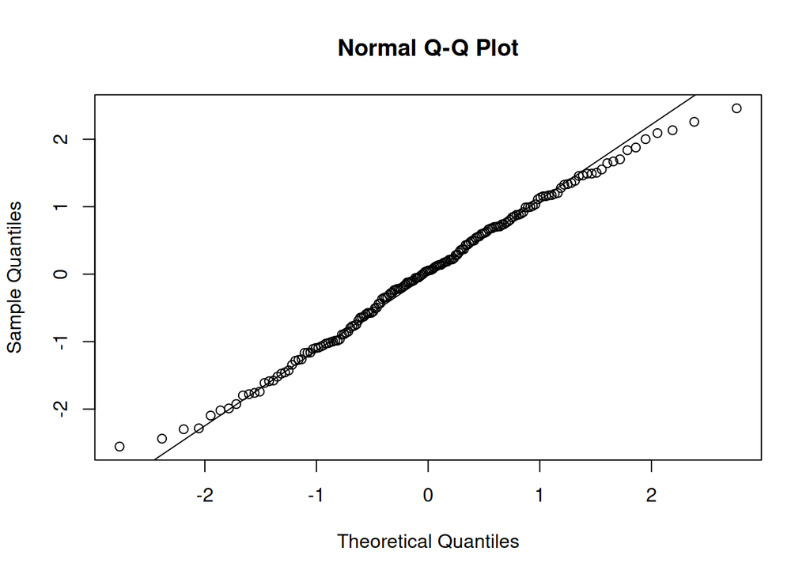

```r
qqnorm(my.model$residuals)
qqline(my.model$residuals)
```

Podemos concluir que os resíduos de fato seguem suficientemente bem uma distribuição normal padrão. Por fim, precisamos de checar a igualdade de variâncias entre cada um dos fatores, ou seja, sua homoscedasticidade.

```r
# Check homoscedasticity
fligner.test(rentabilidade_classificada$Valor ~ rentabilidade_classificada$Ação,
             data = rentabilidade_classificada)
```

```
##
##  Fligner-Killeen test of homogeneity of variances
##
## data:  rentabilidade_classificada$Valor by rentabilidade_classificada$Ação
## Fligner-Killeen:med chi-squared = 3.5484, df = 4, p-value = 0.4706
```

Novamente podemos confirmar a premissa do teste, sendo que o ANOVA se apresenta realmente como um teste confiável para este problema.

# Comparações Múltiplas Entre Níveis

Após a realização do teste ANOVA e a rejeição de $H_0$, conclui-se que pelo menos um dos níveis é significativamente diferente dos demais. Isso indica que uma ou mais ações apresentam resultados superiores às outras. Para identificar quais ações oferecem os melhores retornos, aplica-se o teste de Diferença Significativa Honesta (Honest Significant Difference, HSD) de Tukey, que realiza comparações entre todos os pares de níveis. Esse teste é escolhido em vez de um teste de um contra todos, pois, neste caso, não há um padrão específico a ser usado como referência. Por fim, os intervalos de confiança das diferenças entre os níveis são exibidos para facilitar a interpretação dos resultados.

```r
# Situation 1: all vs. all
library(multcomp)
```

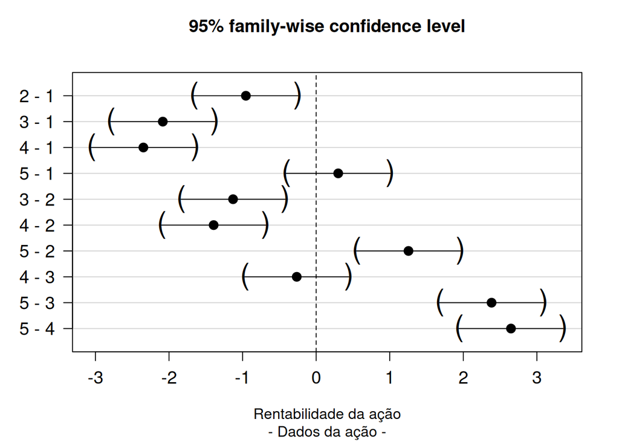

```r
# rentabilidade_classificada.Ação <- rentabilidade_classificada$Ação

m <- mcp(Ação="Tukey")
mc1    <- glht(my.model, linfct=m)
mc1_CI <- confint(mc1, level = 0.95)
plot(mc1_CI,
     xlab       = "Rentabilidade da ação",
     sub        = "- Dados da ação -",
     cex.axis   = 1.2,
     cex        = 2)
```

É perceptível que os intervalos mais positivos são resultados das diferenças entre a ação 5 e as demais, indicando que ela se sobressai em relação às outras. No entanto, ao compará-la com a ação 1, parte do intervalo de confiança inclui valores negativos, impossibilitando concluir, com 95% de confiança, que a ação 5 é mais vantajosa que a ação 1. Observando o boxplot abaixo, percebe-se que a ação 5 apresenta o maior valor mínimo entre as duas. Com base nesse critério, a ação 5 foi escolhida como a mais benéfica.

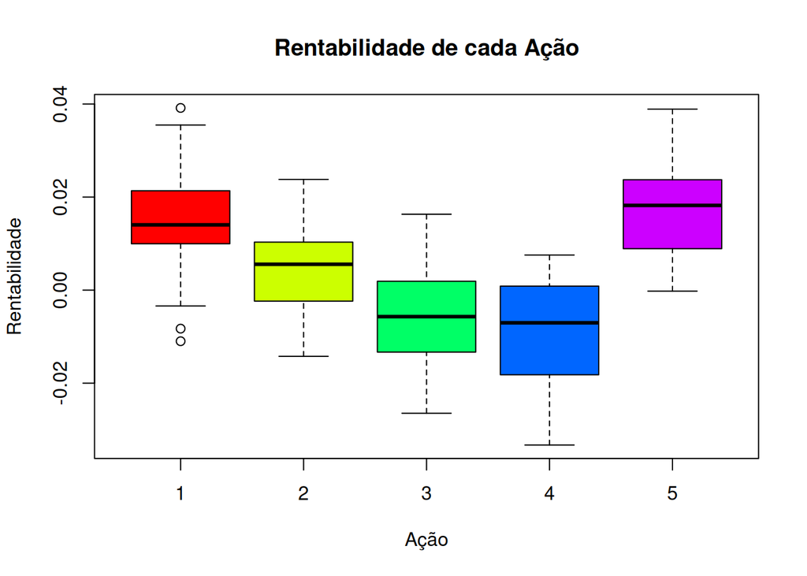

```r
boxplot(rentabilidade,
        main = "Rentabilidade de cada Ação",
        xlab = "Ação",
        ylab = "Rentabilidade",
        col = rainbow(5))
```

Para verificar se o número de amostras utilizado é adequado para realizar o teste de comparação, foi conduzido um teste t considerando um nível de significância ($\alpha$) de 0,05, um poder estatístico de 0,8 e uma diferença mínima detectável ($\delta$) correspondente a um desvio padrão dos dados das ações, o que pode ser tomado frente à homoscedasticidade dos grupos.

```r
sd<-sd(rentabilidade_classificada$Valor)

power.t.test(power = 0.8,
             delta = sd,
             sd = sd,
             sig.level = 0.05,
             type = "two.sample",
             alternative = "two.sided")
```

```
##
##      Two-sample t test power calculation
##
##               n = 16.71477
##           delta = 1.505676
##              sd = 1.505676
##       sig.level = 0.05
##           power = 0.8
##     alternative = two.sided
##
## NOTE: n is number in *each* group
```

O resultado indica que o número mínimo de amostras necessário para os parâmetros especificados é 17. Como foram utilizadas 35 amostras, o requisito é plenamente atendido, garantindo a validade dos testes realizados.

# Discussões e Conclusões

O estudo de caso apresentou uma análise detalhada para a comparação do retorno médio de cinco ações utilizando ferramentas estatísticas, como o teste ANOVA e o teste de Diferença Significativa Honesta (HSD) de Tukey. Através da análise exploratória, constatamos variações nos retornos das ações, reforçando a necessidade de uma avaliação estatística formal para identificar diferenças significativas.

Os resultados do teste ANOVA indicaram que há diferenças estatisticamente significativas entre os grupos analisados. Subsequentemente, o teste de Tukey identificou que a ação 5 se destacou em relação às demais, apresentando o maior valor mínimo e resultados positivos consistentes. No entanto, ao compará-la diretamente com a ação 1, o intervalo de confiança incluiu valores negativos, impossibilitando afirmar com 95% de confiança que a ação 5 é significativamente superior à ação 1.

O número de amostras utilizado (35 por grupo) foi avaliado como adequado para garantir a validade estatística dos testes, superando o valor mínimo necessário de 17 amostras por grupo. Isso reforça a robustez dos resultados obtidos e a confiabilidade das conclusões.

Embora os resultados sejam consistentes dentro das premissas assumidas, o estudo apresenta limitações, como a suposição de homoscedasticidade entre os grupos e a ausência de dados adicionais para avaliação de outros fatores que podem influenciar os retornos das ações. Estudos futuros poderiam explorar a inclusão de variáveis macroeconômicas, como taxa de juros ou volatilidade do mercado, para enriquecer a análise e refinar as conclusões.

Em resumo, a metodologia empregada demonstrou ser eficaz na identificação de diferenças entre as ações analisadas, destacando a ação 5 como a mais promissora dentro do conjunto avaliado. Essa abordagem pode ser replicada em outros contextos de seleção de ativos, contribuindo para decisões de investimento mais embasadas e estratégicas.

# Bibliografia

[1]

P. Xidonas, R. Steuer, and C. Hassapis, “Robust portfolio optimization: A categorized bibliographic review,” *Annals of Operations Research*, vol. 292, no. 1, pp. 533–552, 2020.

[2]

K. Levišauskait, “Investment analysis and portfolio management,” *Leonardo da Vinci programme project*, vol. 7, 2010.